# **Milestone 2**

### **Decision Tree**

https://scikit-learn.org/stable/auto_examples/tree/plot_tree_regression.html

```python
# Decision Tree Regressor
dt_regressor = DecisionTreeRegressor(random_state = 1)

# Fitting the model
dt_regressor.fit(X_train, y_train)

# Model Performance on test data i.e prediction


dt_regressor_perf_test = model_performance_regression(dt_regressor, X_test, y_test)

dt_regressor_perf_test
```

|  | RMSE | MAE | R-squared | Adj. R-squared | MAPE |
| --- | --- | --- | --- | --- | --- |
| 0 | 0.283967 | 0.194541 | 0.895595 | 0.892314 | inf |

```python
pred_train = dt_regressor.predict(X_train)
pred_test = dt_regressor.predict(X_test)
train_r2 = metrics.r2_score(y_train, pred_train)
test_r2 = metrics.r2_score(y_test, pred_test)
train_rmse = metrics.mean_squared_error(y_train, pred_train, squared = False)
test_rmse = metrics.mean_squared_error(y_test, pred_test, squared = False)

score_list = []
score_list.extend((train_r2, test_r2, train_rmse, test_rmse))

# If the flag is set to True then only the following print statements will be dispayed, the default value is True

print("R-square on training set : ", metrics.r2_score(y_train, pred_train))

print("R-square on test set : ", metrics.r2_score(y_test, pred_test))

print("RMSE on training set : ", np.sqrt(metrics.mean_squared_error(y_train, pred_train)))

print("RMSE on test set : ", np.sqrt(metrics.mean_squared_error(y_test, pred_test)))
```

```
R-square on training set :  0.9999903038539666
R-square on test set :  0.8955948180142763
RMSE on training set :  0.002712418113189585
RMSE on test set :  0.28396663469685146
```

There has to be overtraining or overfitting here, as the R^2 value is nearly perfect with very minimal RMSE. Not true for the testing set.

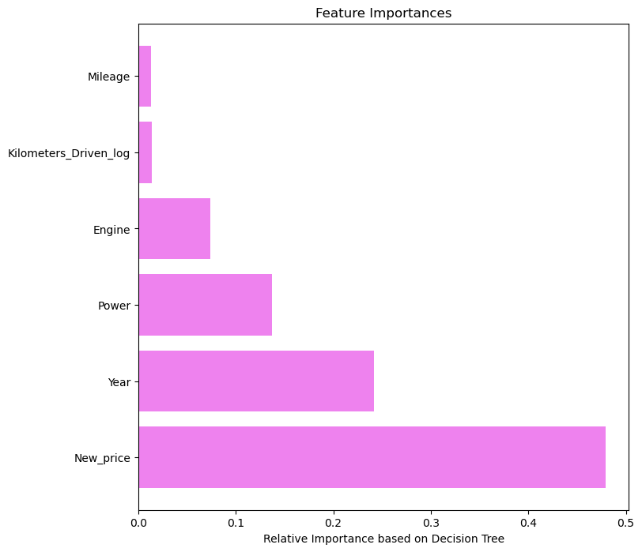

```python
# Plotting the feature importance

threshold = 0.01

important_features = np.where(dt_regressor.feature_importances_ > threshold)[0]

important_scores = dt_regressor.feature_importances_[important_features]

important_names = X.columns[important_features]

sorted_idx = important_scores.argsort()[::-1]
important_scores = important_scores[sorted_idx]
important_names = important_names[sorted_idx]

plt.figure(figsize = (8, 8))

plt.title('Feature Importances')

plt.barh(range(len(important_scores)), important_scores, color = 'violet', align = 'center')

plt.yticks(range(len(important_scores)), important_names)

plt.xlabel('Relative Importance based on Decision Tree')

plt.show()
```

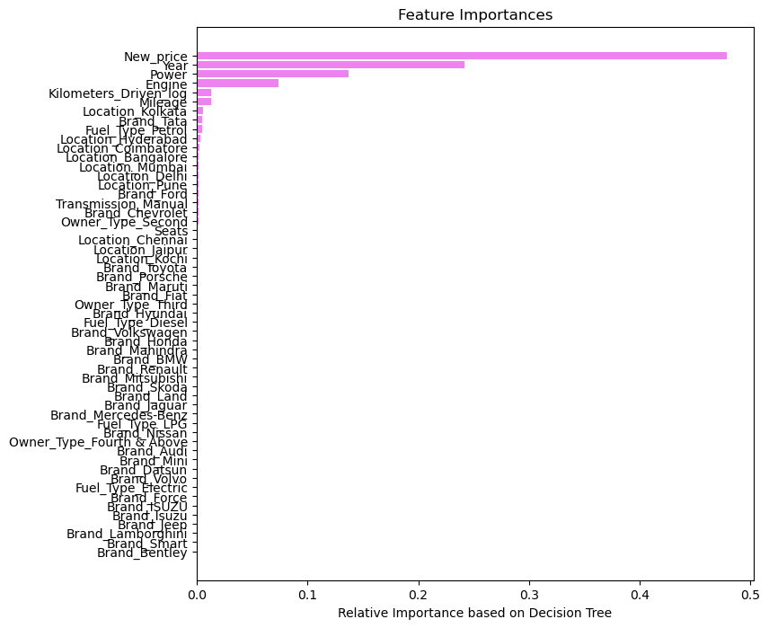

```python
# Plotting the feature importance


features = list(X.columns)

importances = dt_regressor.feature_importances_
indices = np.argsort(importances)

plt.figure(figsize = (8, 8))

plt.title('Feature Importances')

plt.barh(range(len(indices)), importances[indices], color = 'violet', align = 'center')

plt.yticks(range(len(indices)), [features[i] for i in indices])

plt.xlabel('Relative Importance based on Decision Tree')

plt.show()
```

```python
print(pd.DataFrame(dt_regressor.feature_importances_, columns = ["Imp"], index = X_train.columns).sort_values(by = 'Imp', ascending = False))
```

```
                                    Imp
New_price                  4.789162e-01
Year                       2.415222e-01
Power                      1.368547e-01
Engine                     7.408695e-02
Kilometers_Driven_log      1.338021e-02
Mileage                    1.298468e-02
Location_Kolkata           5.539022e-03
Brand_Tata                 4.696025e-03
Fuel_Type_Petrol           4.599421e-03
Location_Hyderabad         3.198792e-03
Location_Coimbatore        2.238177e-03
Location_Bangalore         1.900927e-03
Location_Mumbai            1.831025e-03
Location_Delhi             1.552992e-03
Location_Pune              1.528289e-03
Brand_Ford                 1.386816e-03
Transmission_Manual        1.341096e-03
Brand_Chevrolet            1.313598e-03
Owner_Type_Second          1.302076e-03
Seats                      1.192824e-03
Location_Chennai           1.131706e-03
Location_Jaipur            9.896268e-04
Location_Kochi             9.209152e-04
Brand_Toyota               8.283647e-04
Brand_Porsche              5.765446e-04
Brand_Maruti               5.198810e-04
Brand_Fiat                 4.823711e-04
Owner_Type_Third           4.699765e-04
Brand_Hyundai              4.398492e-04
Fuel_Type_Diesel           3.280446e-04
Brand_Volkswagen           3.243255e-04
Brand_Honda                3.208651e-04
Brand_Mahindra             2.578809e-04
Brand_BMW                  1.593182e-04
Brand_Renault              1.515180e-04
Brand_Mitsubishi           1.512941e-04
Brand_Skoda                1.389274e-04
Brand_Land                 1.384204e-04
Brand_Jaguar               1.146910e-04
Brand_Mercedes-Benz        4.523091e-05
Fuel_Type_LPG              4.232964e-05
Brand_Nissan               3.713562e-05
Owner_Type_Fourth & Above  3.685737e-05
Brand_Audi                 1.645538e-05
Brand_Mini                 9.422728e-06
Brand_Datsun               2.011141e-06
Brand_Volvo                5.137872e-09
Brand_Lamborghini          0.000000e+00
Brand_Jeep                 0.000000e+00
Brand_Isuzu                0.000000e+00
Brand_Smart                0.000000e+00
Brand_ISUZU                0.000000e+00
Brand_Force                0.000000e+00
Fuel_Type_Electric         0.000000e+00
Brand_Bentley              0.000000e+00
```

Print the importance of features in the tree building. The importance of a feature is computed as the (normalized) total reduction of the criterion brought by that feature. It is also known as the Gini importance.

### **Random Forest**

https://scikit-learn.org/stable/modules/generated/sklearn.ensemble.RandomForestRegressor.html

```python
# Import Randomforest for Regression from sklearn
from sklearn.ensemble import RandomForestRegressor
```

```python
# Create a Randomforest regression model
rf_regressor = RandomForestRegressor(n_estimators = 100, random_state = 1)
```

```python
# Fit Randomforest regression model
rf_regressor.fit(X_train, y_train)
```

```
RandomForestRegressor(random_state=1)
```

```python
# Model Performance on the test data
forest_regressor_perf_test = model_performance_regression(rf_regressor, X_test, y_test)

forest_regressor_perf_test
```

|  | RMSE | MAE | R-squared | Adj. R-squared | MAPE |
| --- | --- | --- | --- | --- | --- |
| 0 | 0.202587 | 0.144514 | 0.946861 | 0.945191 | inf |

```python
# Get score of the model
pred_train = rf_regressor.predict(X_train)
pred_test = rf_regressor.predict(X_test)
train_r2 = metrics.r2_score(y_train, pred_train)
test_r2 = metrics.r2_score(y_test, pred_test)
train_rmse = metrics.mean_squared_error(y_train, pred_train, squared = False)
test_rmse = metrics.mean_squared_error(y_test, pred_test, squared = False)

score_list = []
score_list.extend((train_r2, test_r2, train_rmse, test_rmse))

# If the flag is set to True then only the following print statements will be dispayed, the default value is True

print("R-square on training set : ", metrics.r2_score(y_train, pred_train))

print("R-square on test set : ", metrics.r2_score(y_test, pred_test))

print("RMSE on training set : ", np.sqrt(metrics.mean_squared_error(y_train, pred_train)))

print("RMSE on test set : ", np.sqrt(metrics.mean_squared_error(y_test, pred_test)))
```

```
R-square on training set :  0.991681620544162
R-square on test set :  0.9468612323866998
RMSE on training set :  0.07944680303508384
RMSE on test set :  0.2025872113408945
```

```python
print(rf_regressor.get_params())
```

[output not shown]

```python
scores = cross_val_score(rf_regressor, X, y, cv=5, scoring='r2')
print('R-squared scores:', scores)
yue = np.mean(scores)
yue
```

```
R-squared scores: [0.95311159 0.92822172 0.93578957 0.94404016 0.93817424]
```

```
0.9398674561408086
```

**Observations and insights: There has to be overtraining or overfitting here, as the R^2 value is nearly perfect with very minimal RMSE. Not true for the testing set.**

**Feature Importance**

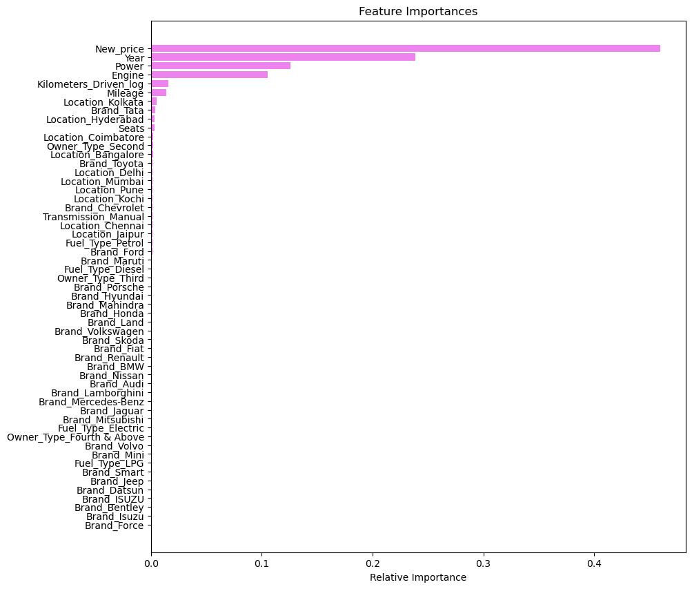

```python
# Print important features similar to decision trees
importances = rf_regressor.feature_importances_

indices = np.argsort(importances)

plt.figure(figsize = (10, 10))

plt.title('Feature Importances')

plt.barh(range(len(indices)), importances[indices], color = 'violet', align = 'center')

plt.yticks(range(len(indices)), [features[i] for i in indices])

plt.xlabel('Relative Importance')

plt.show()
```

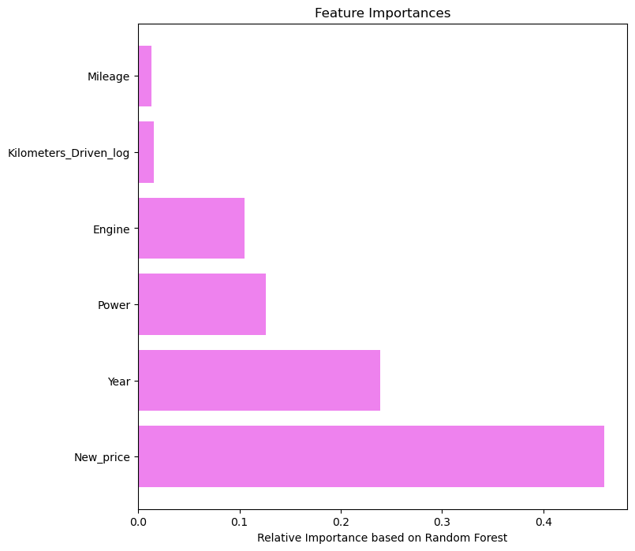

```python
# Plotting the feature importance

threshold = 0.01

important_features = np.where(rf_regressor.feature_importances_ > threshold)[0]

important_scores = rf_regressor.feature_importances_[important_features]

important_names = X.columns[important_features]

sorted_idx = important_scores.argsort()[::-1]
important_scores = important_scores[sorted_idx]
important_names = important_names[sorted_idx]

plt.figure(figsize = (8, 8))

plt.title('Feature Importances')

plt.barh(range(len(important_scores)), important_scores, color = 'violet', align = 'center')

plt.yticks(range(len(important_scores)), important_names)

plt.xlabel('Relative Importance based on Random Forest')

plt.show()
```

**Observations and insights: New price, year, power, and engine are the most important features, just like in the decision tree.**

### **Hyperparameter Tuning: Decision Tree**

```python
# Choose the type of estimator
dtree_tuned = DecisionTreeRegressor(random_state = 1)

# Grid of parameters to choose from
# Check documentation for all the parametrs that the model takes and play with those
parameters = {'max_depth': np.arange(2, 8),

              'criterion': ['squared_error', 'friedman_mse'],

              'min_samples_leaf': [1, 3, 5, 7],

              'max_leaf_nodes': [2, 5, 7] + [None]}

# Type of scoring used to compare parameter combinations
scorer = make_scorer(r2_score)

# Run the grid search

grid_obj = GridSearchCV(dtree_tuned, parameters, scoring = scorer, cv = 5)

grid_obj = grid_obj.fit(X_train,y_train)

# Set the model to the best combination of parameters
dtree_tuned_regressor = grid_obj.best_estimator_

# Fit the best algorithm to the data
dtree_tuned_regressor.fit(X_train, y_train)
```

```
DecisionTreeRegressor(max_depth=7, min_samples_leaf=5, random_state=1)
```

```python
# Get score of the dtree_tuned
dtree_tuned_regressor_perf_test = model_performance_regression(dtree_tuned_regressor, X_test, y_test)
dtree_tuned_regressor_perf_test
```

|  | RMSE | MAE | R-squared | Adj. R-squared | MAPE |
| --- | --- | --- | --- | --- | --- |
| 0 | 0.283314 | 0.217045 | 0.896074 | 0.892808 | inf |

```python
# Get score of the model
pred_train = dtree_tuned_regressor.predict(X_train)
pred_test = dtree_tuned_regressor.predict(X_test)
train_r2 = metrics.r2_score(y_train, pred_train)
test_r2 = metrics.r2_score(y_test, pred_test)
train_rmse = metrics.mean_squared_error(y_train, pred_train, squared = False)
test_rmse = metrics.mean_squared_error(y_test, pred_test, squared = False)

score_list = []
score_list.extend((train_r2, test_r2, train_rmse, test_rmse))

# If the flag is set to True then only the following print statements will be dispayed, the default value is True

print("R-square on training set : ", metrics.r2_score(y_train, pred_train))

print("R-square on test set : ", metrics.r2_score(y_test, pred_test))

print("RMSE on training set : ", np.sqrt(metrics.mean_squared_error(y_train, pred_train)))

print("RMSE on test set : ", np.sqrt(metrics.mean_squared_error(y_test, pred_test)))
```

```
R-square on training set :  0.9171353718829989
R-square on test set :  0.8960744518466021
RMSE on training set :  0.25075041174261165
RMSE on test set :  0.28331361734877125
```

**Observations and insights: Hypertuning the decision tree has removed some overfitting here and the RMSE and R^2 scores between test and training seem similar now.**

**Feature Importance**

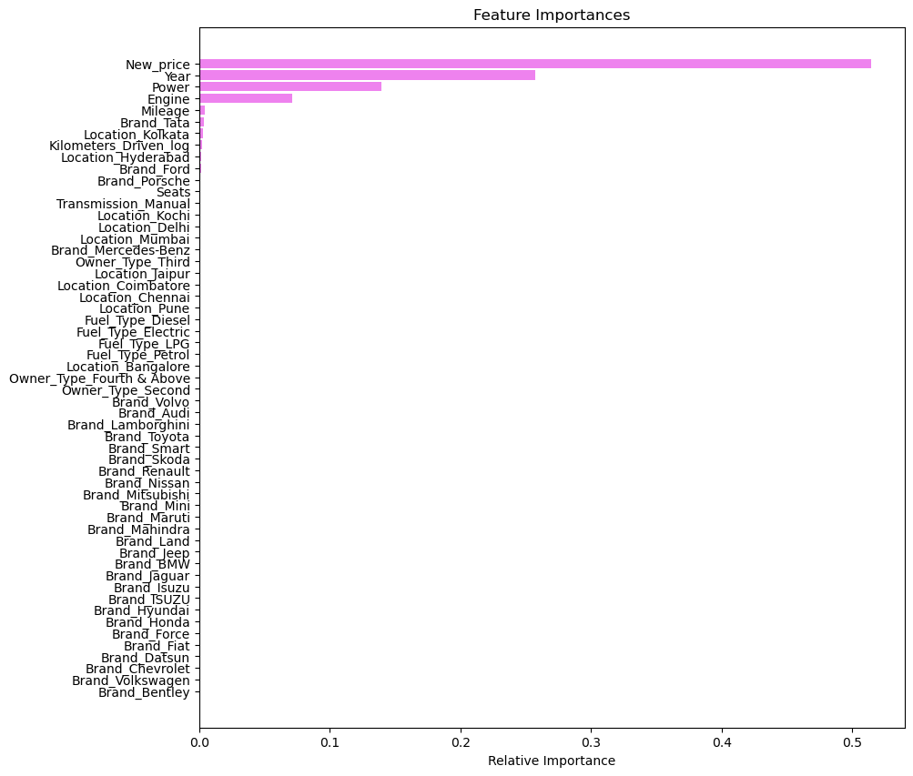

```python
# Print important features of tuned decision tree similar to decision trees
# Plotting the feature importance
features = list(X.columns)

importances = dtree_tuned_regressor.feature_importances_

indices = np.argsort(importances)

plt.figure(figsize = (10, 10))

plt.title('Feature Importances')

plt.barh(range(len(indices)), importances[indices], color = 'violet', align = 'center')

plt.yticks(range(len(indices)), [features[i] for i in indices])

plt.xlabel('Relative Importance')

plt.show()
```